# 2. domaca naloga

Bayesova statistika

Tom Rupnik Medjedovic in Neza Krzan

*Za primer iz 3. sklopa (uporabite zgornje podatke, model z $\sigma^2=0.1^2$ in zgornjo apriorno porazdelitev z $\mu_0=1.78$ in $\sigma_0^2 = 0.2^2$ – ti parametri so fiksni) aproksimirajte aposteriorno porazdelitev s pomocjo algoritma Metropolis-Hastings, kjer sledite spodnjim korakom.*

# Algoritem Metropolis-Hastings za ocenjevanje enega parametra

*1. Sami v R-u sprogramirajte algoritem Metropolis-Hastings za primer ocenjevanja enega parametra oz. za nas primer. Kljucno je, da ga sprogramirate sami, pri cemer splosnost kode in efektivnost implementacije nista pomembni. (Za ta preprost primer boste npr. 40000 iteracij dobili v zelo kratkem casu, ne glede na izbor parametrov v spodnjih tockah ali efektivnost implementacije.)*

```r
# Funkcija verjetja
verjetje <- function(theta, x, sigma){
  #cleni <- 1/(sqrt(2*pi)*sigma)* exp(-(x-theta)^2/(2*sigma^2))
  #return(prod(cleni))
  return(prod(dnorm(x, theta, sigma)))
}

# Apriorna porazdelitev
apriorna_porazdelitev <- function(theta, mu_0, sigma_0){
  return(dnorm(theta, mu_0, sigma_0))
}

#q funkcija
q <- function(theta_zvezdica, theta, sigma) {
  return(dnorm(theta_zvezdica, theta, sigma))
}
```

```r
metropolis_hastings <- function(n_itr, x, theta_zacetek, sigma, mu_0, sigma_0){
  # n_itr = ponovitve
  # x = podatki
  # theta_zacetek = theta s katero zacnemo in jo posodabljamo
  # sigma = sigma zacetnega modela
  # mu_0 in sigma_0 = parametra apriorne porazdelitve

  # Prazen vektor za shranjevanje
  theta <- numeric(n_itr)
  # Zacetna vrednost thete
  theta[1] <- theta_zacetek

  for(i in 2:n_itr){
    # Nova theta
    theta_zvezdica <- rnorm(1, theta[i - 1], sigma)

    # aposteriorna in verjetje s theta_zvezdica
    aposteriorna_zvezdica <- apriorna_porazdelitev(theta_zvezdica, mu_0, sigma_0)
    verjetje_zvezdica <- verjetje(theta_zvezdica, x, sigma)
    q_zvezdica <- q(theta[i - 1], theta_zvezdica, sigma)

    # aposteriorna in verjetje s theta_i
    aposteriorna_i <- apriorna_porazdelitev(theta[i - 1], mu_0, sigma_0)
    verjetje_i <- verjetje(theta[i - 1], x, sigma)
    q_i <- q(theta_zvezdica, theta[i - 1], sigma)

    # alpha
    alpha <- min(1, (aposteriorna_zvezdica * verjetje_zvezdica * q_zvezdica) / (aposteriorna_i * verjetje_i * q_i))

    # sprejmemo ali zavrnemo
    if(runif(1) < alpha){
        theta[i] <- theta_zvezdica # "accept" -> min(1, A)
        }
    else{
      theta[i] <- theta[i - 1] # "reject"  -> theta_i
      }
    }

  return(theta)
}
```

# Preizkus algoritma

*2. Preizkusite ga na nasem primeru, kjer si sami izberite neko smiselno zacetno vrednost in varianco predlagalne porazdelitve. Rezultate predstavite na naslednji nacin:*  
*- Narisite celotno dobljeno zaporedje $\theta^{(i)}$ (glede na iteracije $i$).*  
*- Narisite le prvih 500 ali pa 5000 clenov.*  
*- Narisite celotno zaporedje, kjer uporabite ustrezen *burn-in*.*  
*- Za tako izbrano zaporedje graficno predstavite aposteriorno porazdelitev in jo graficno primerjajte s pravo aposteriorno porazdelitvijo.*  
*- Ocenite parameter in 95% interval zaupanja za parameter iz izbranega zaporedja ter primerjajte z ocenami iz prave aposterirone porazdelitve.*

Najprej algoritem stestirava na podatkih iz vaj, z naslednjimi vrednostmi  
$n_{itr}=40000,$  
$x \dots$ vzorec visin (metri) studentov moskega spola  
$\theta^0 = 1.5,$  
$\sigma^2=0.1^2,$  
$\mu_0 = 1.78,$  
$\sigma_0^2 = 0.2^2,$  
kjer $\theta^0$ predstavlja zacetni $\theta$, ki ga predlagamo v algoritmu in $\sigma$ predstavlja varianco predlagalne porazdelitve.

```r
# Nastavitev parametrov
n_itr <- 40000

x <- c(1.91, 1.94, 1.68, 1.75, 1.81, 1.83, 1.91, 1.95, 1.77, 1.98,
       1.81, 1.75, 1.89, 1.89, 1.83, 1.89, 1.99, 1.65, 1.82, 1.65,
       1.73, 1.73, 1.88, 1.81, 1.84, 1.83, 1.84, 1.72, 1.91, 1.63)

theta_zacetek <- 1.5

sigma <- 0.1
mu_0 <- 1.78
sigma_0 <- 0.2

# Test algoritma
theta <- metropolis_hastings(n_itr, x, theta_zacetek, sigma, mu_0, sigma_0)
```

```r
# Prava aposteriorna porazdelitev
n <- length(x)

prec <- 1/sigma^2
prec0 <- 1/sigma_0^2
prec.n <- prec0 + n*prec
sigma.n <- sqrt(1/prec.n)

mu.n <- prec0/prec.n * mu_0 + n*prec/prec.n * mean(x)
```

## Graf celotnega zaporedja

Narisemo celotno dobljeno zaporedje $\theta^{(i)}$ (glede na iteracije $i$).

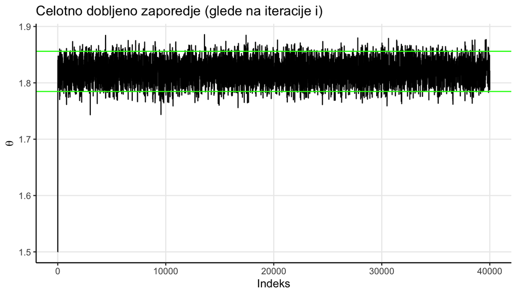

```r
df <- data.frame(theta = theta)

ggplot(df, aes(x=1:nrow(df), y=theta)) +
    geom_line() +
    labs(title="Celotno dobljeno zaporedje (glede na iteracije i)",
         x="Indeks",
         y=expression(theta)) +
    # zelena crta
    geom_hline(yintercept = c(qnorm(0.025, mu.n, sigma.n),qnorm(0.975, mu.n, sigma.n)),
               color = "green") +
    theme_bw() +
    theme(panel.border = element_blank(),
              panel.grid.minor = element_blank(),
              axis.line = element_line(colour = "black"),
          legend.position = "none")
```

Na sliki sva za boljso predstavo oznacila 95% referencni interval prave aposterirone porazdelitve (zeleni crti).

## Prvih 500 in 5000 clenov zaporedja

Graf prvih 500 in 5000 clenov.

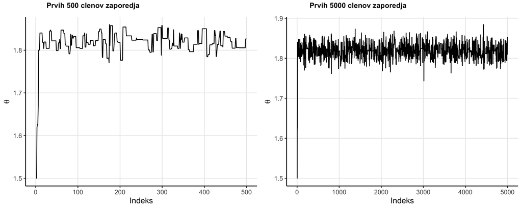

## Celotno zaporedje z ustreznim *burn-in*

```r
metropolis_hastings_burn_in <- function(n_itr, x, theta_zacetek, sigma, mu_0, sigma_0){
  # n_itr = ponovitve
  # x = podatki
  # theta_zacetek = theta s katero zacnemo in jo posodabljamo
  # sigma = sigma zacetnega modela
  # mu_0 in sigma_0 = parametra apriorne porazdelitve

  # pridobimo theto
  theta <- metropolis_hastings(n_itr, x, theta_zacetek, sigma, mu_0, sigma_0)

  # v primeru burn in (odstranimo prvih 10% vzorca)
  n_burn_in = n_itr*0.1
  theta = theta[n_burn_in:length(theta)]

  return(theta)
}

# Test algoritma
theta <- metropolis_hastings_burn_in(n_itr, x, theta_zacetek, sigma, mu_0, sigma_0)
```

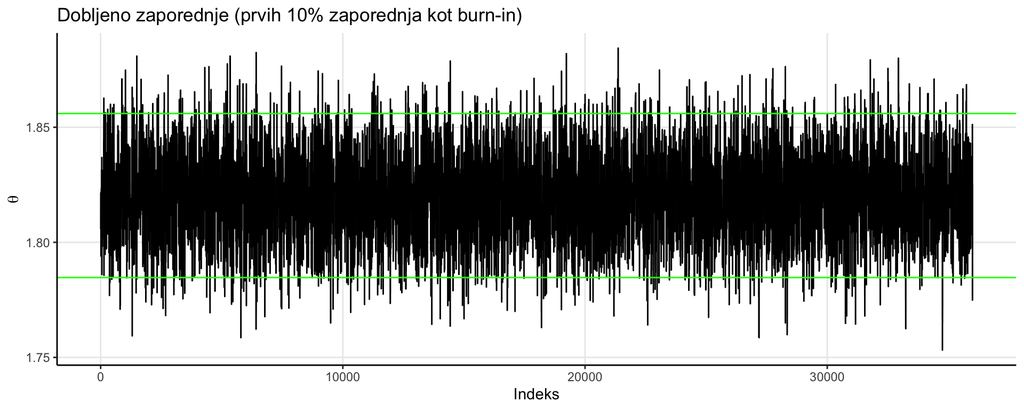

Na sliki sva za boljso predstavo oznacila 95% referencni interval prave aposterirone porazdelitve (zeleni crti).

## Aposteriorna porazdelitev in primerjava s pravo aposteriorno porazdelitvijo

Za tako izbrano zaporedje sva graficno predstavila aposteriorno porazdelitev in jo graficno primerjajla s pravo aposteriorno porazdelitvijo.

[figure not shown]

## Ocena parametra in 95% interval zaupanja za parameter

Poglejmo si se oceno za parameter $\theta$ in pripadajoc interval zaupanja za nas algoritem. Zaradi simetricnosti porazdelitve sva lahko za oceno parametra $\theta$ izbrala povprecje.

```r
mh_alg <- rbind(mean(df %>% slice(1001:n()) %>% unlist()), mu.n)

ocena_pap <- rbind(quantile(df %>% slice(1001:n()) %>%
                         unlist(), probs=c(0.025, 0.975)),
              c(qnorm(0.025, mean=mu.n, sd=sigma.n), qnorm(0.975, mean=mu.n, sd=sigma.n)))

primerjava <- cbind(mh_alg, ocena_pap)

colnames(primerjava) <- c("Povprecje", "2.5%", "97.5%")
rownames(primerjava) <- c("Metropolis-Hastings algoritem", "Ocena iz prave aposteriorne porazdelitve")

kable(primerjava, digits=5, booktabs=T) %>%
    kable_styling(latex_options=c("striped", "hold_position"), full_width=FALSE)
```

|  | Povprecje | 2.5% | 97.5% |
| --- | --- | --- | --- |
| Metropolis-Hastings algoritem | 1.81981 | 1.78480 | 1.85536 |
| Ocena iz prave aposteriorne porazdelitve | 1.82033 | 1.78469 | 1.85597 |

# Zacetna vrednost $\theta$

*3. Pozenite vas algoritem pri neki nesmiselni zacetni vrednosti. **Pozor:** ce boste $\alpha$ implementirali po formuli iz str. 2, potem algoritem pri zelo nesmiselnih zacetnih vrednostih ne bo deloval – zato je potrebno implementirati na ravni logaritma (primerno prilagodite korake algoritma). Rezultate predstavite:*  
*- Za visje tocke domace naloge: Opisite, zakaj konkretno so se pojavile tezave, ce ste uporabili zelo nesmiselno zacetno vrednost in osnovno verzijo algoritma (brez logaritmiranja). Algoritem ustrezno implementirajte tako, da bo deloval tudi pri zelo nesmiselnih zacetnih vrednostih.*  
*- Ce zgornje ne uspete narediti, pustite algoritem v osnovni varianti in izberite nekoliko manj nesmiselno zacetno vrednost.*  
*- Narisite celotno dobljeno zaporedje $\theta^{(i)}$ (glede na iteracije $i$).*  
*- Narisite le prvih 500 ali pa 5000 clenov.*  
*- Narisite celotno zaporedje, kjer uporabite ustrezen *burn-in*.*

Glede na to, da nas zanima visina studentov moskega spola, sva si za nesmiselno zacetno vrednost izbrala $\theta_{\text{zacetek}} = 0$, saj je nemogoce, da bi bila visina $0$. Vsi ostali parametri ostanejo enaki kot prej. Pri zagonu funkcije

```r
# Nastavim nesmiselno zacetno theto, ostali parametri ostanejo enako
theta_zacetek <- 0
# zakomentirano, da se koda ne izvede
#theta <- metropolis_hastings(n_itr, x, theta_zacetek, sigma, mu_0, sigma_0)
```

se pojavi napaka

`Error in if (runif(1) < alpha) { : missing value where TRUE/FALSE needed`.

Vidiva, da je problem v if stavku pri primerjavi `runif(1)` in `alpha` ($\alpha$). V `runif(1)` ne more biti tezava, torej je problem le v izracunu $\alpha$. Nacin, kako sva izracunala $\alpha$ je naslednji

`alpha <- min(1, (aposteriorna_zvezdica * verjetje_zvezdica * q_zvezdica) / (aposteriorna_i * verjetje_i * q_i))`.

Problem lahko nastane, ko je kaksen izmed clenov `aposteriorna_i` in `verjetje_i` enak $0$, saj potem pride do deljenja z $0$. Ce pogledamo kaj vrnejo te funkcije v primeru $\theta_{\text{zacetek}} = 0$

```r
verjetje(0, x, sigma)
```

```
## [1] 0
```

```r
apriorna_porazdelitev(0, mu_0, sigma_0)
```

```
## [1] 1.257903e-17
```

Vidimo, da je verjetje enako $0$, torej takoj delimo z $0$. Zato bomo celoten algoritem implementirali z logaritmom, da bo delovalo tudi pri zelo nesmiselnih zacetnih vrednostih.

Najprej ustrezno implementirava vse potrebne funkcije za algoritem.

```r
# Funkcija verjetja
verjetje_log <- function(theta, x, sigma){
    return(sum(dnorm(x, theta, sigma, log=TRUE)))
}

# Apriorna porazdelitev
apriorna_porazdelitev_log <- function(theta, mu_0, sigma_0){
  return(dnorm(theta, mu_0, sigma_0, log=TRUE))
}

#q funkcija
q_log <- function(theta_zvezdica, theta, sigma){
  return(dnorm(theta_zvezdica, theta, sigma, log=TRUE))
}
```

nato pa se algoritem

```r
metropolis_hastings_log <- function(n_itr, x, theta_zacetek, sigma, mu_0, sigma_0, delez = FALSE){
  # n_itr = ponovitve
  # x = podatki
  # theta_zacetek = theta s katero zacnemo in jo posodabljamo
  # sigma = sigma zacetnega modela
  # mu_0 in sigma_0 = parametra apriorne porazdelitve

  # Prazen vektor za shranjevanje
  theta <- numeric(n_itr)
  # Zacetna vrednost thete
  theta[1] <- theta_zacetek

  koliko = 0

  for(i in 2:n_itr){
    # Nova theta
    theta_zvezdica <- rnorm(1, theta[i - 1], sigma)

    # aposteriorna in verjetje s theta_zvezdica (uporabiva implementirane funkcije)
    aposteriorna_zvezdica <- apriorna_porazdelitev_log(theta_zvezdica, mu_0, sigma_0)
    verjetje_zvezdica <- verjetje_log(theta_zvezdica, x, sigma)
    q_zvezdica <- q_log(theta[i - 1], theta_zvezdica, sigma)

    # aposteriorna in verjetje s theta_i (uporabiva implementirane funkcije)
    aposteriorna_i <- apriorna_porazdelitev_log(theta[i - 1], mu_0, sigma_0)
    verjetje_i <- verjetje_log(theta[i - 1], x, sigma)
    q_i <- q_log(theta_zvezdica, theta[i - 1], sigma)

    # alpha(tukaj se spremeni, + nadomesti * in - nadomesti /)
    alpha <- min(1, exp((aposteriorna_zvezdica + verjetje_zvezdica + q_zvezdica) - (aposteriorna_i + verjetje_i + q_i)))

    # sprejmemo ali zavrnemo
    if(runif(1) < alpha){
        koliko = koliko + 1
        theta[i] <- theta_zvezdica # "accept" -> min(1, A)
        }
    else{
      theta[i] <- theta[i - 1] # "reject"  -> theta_i
      }
    }

  if (delez){
    return(c(theta, koliko/n_itr))
  } else{
    return(theta)
  }
}

# Test algoritma
theta <- metropolis_hastings_log(n_itr, x, theta_zacetek, sigma, mu_0, sigma_0)
```

## Graf celotnega zaporedja

Ponovno algoritem stestirava na podatkih iz vaj, z naslednjimi vrednostmi  
$n_{itr}=40000,$  
$x \dots$ vzorec visin (metri) studentov moskega spola  
$\theta^0 = 1.5,$  
$\sigma^2=0.1^2,$  
$\mu_0 = 1.78,$  
$\sigma_0^2 = 0.2^2,$.

Narisemo celotno dobljeno zaporedje $\theta^{(i)}$ (glede na iteracije $i$).

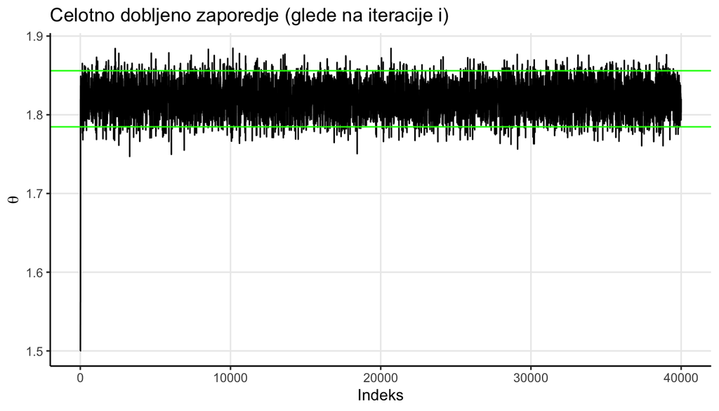

```r
theta_zacetek <- 1.5
theta <- metropolis_hastings_log(n_itr, x, theta_zacetek, sigma, mu_0, sigma_0)

df_log <- data.frame(theta = theta)

ggplot(df_log, aes(x=1:nrow(df_log), y=theta)) +
    geom_line() +
    labs(title="Celotno dobljeno zaporedje (glede na iteracije i)",
         x="Indeks",
         y=expression(theta)) +
    # zelena crta
    geom_hline(yintercept = c(qnorm(0.025, mu.n, sigma.n),qnorm(0.975, mu.n, sigma.n)),
               color = "green") +
    theme_bw() +
    theme(panel.border = element_blank(),
              panel.grid.minor = element_blank(),
              axis.line = element_line(colour = "black"),
          legend.position = "none")
```

Na sliki sva za boljso predstavo oznacila 95% referencni interval prave aposterirone porazdelitve (zeleni crti).

## Prvih 500 in 5000 clenov zaporedja

Graf prvih 500 in 5000 clenov.

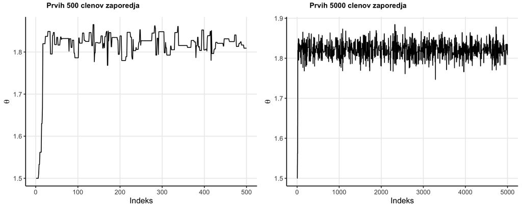

## Celotno zaporedje z ustreznim *burn-in*

```r
metropolis_hastings_log_burn_in <- function(n_itr, x, theta_zacetek, sigma, mu_0, sigma_0, burn_in = FALSE){
  # n_itr = ponovitve
  # x = podatki
  # theta_zacetek = theta s katero zacnemo in jo posodabljamo
  # sigma = sigma zacetnega modela
  # mu_0 in sigma_0 = parametra apriorne porazdelitve

  # pridobimo theto
  metropolis_hastings_log(n_itr, x, theta_zacetek, sigma, mu_0, sigma_0)

  # v primeru burn in (odstranimo prvih 10% vzorca)
  n_burn_in = n_itr*0.1
  theta = theta[n_burn_in:length(theta)]

  return(theta)
}

# Test algoritma
theta <- metropolis_hastings_log_burn_in(n_itr, x, theta_zacetek, sigma, mu_0, sigma_0)
```

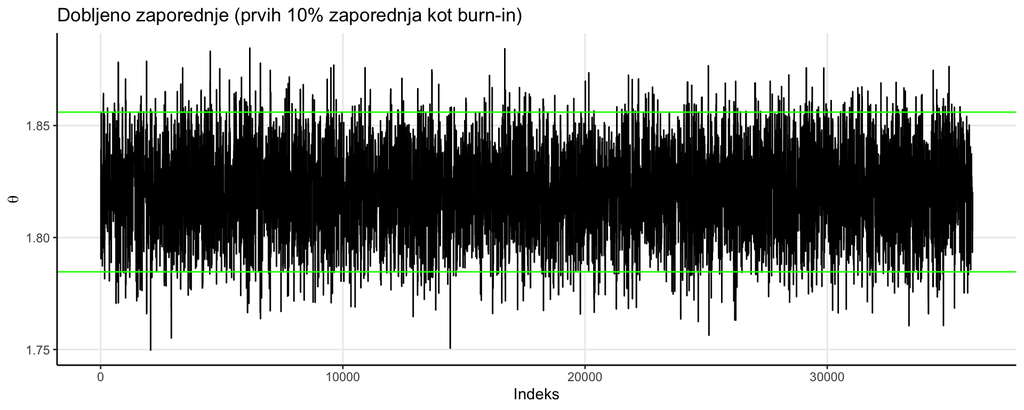

# Razlicne variance

*4. Pri neki smiselni zacetni vrednosti pozenite algoritem pri nekaj razlicnih variancah za predlagalno porazdelitev. Pri izboru pretiravajte v obe smeri (spomnite se, kaksni so po velikosti nasi podatki), tako da boste graficno opazili razlike na prvih npr. 500 iteracijah. Rezultate predstavite:*  
*- Za vsak primer narisite prvih nekaj (nekje med 500 in 5000) clenov in se celotno zaporedje.*  
*- Komentirajte razlike in zakaj do njih pride. Kaj in zakaj vas moti pri izbranih primerih?*  
*- **Bonus vprasanje (ne steje v osnovne tocke domace naloge):** Kaksen bi bil v splosnem (ne vezano na nas vzorec) vas predlog glede izbora variance predlagalne porazdelitve oz. kaksen bi bil predlog za izbor koncnega zaporedja?*

## Prvih nekaj clenov in celotno zaporedje

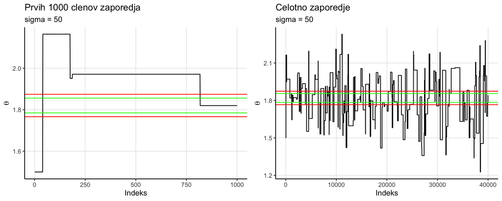

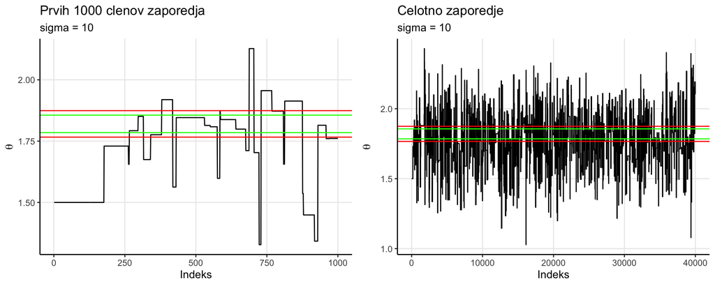

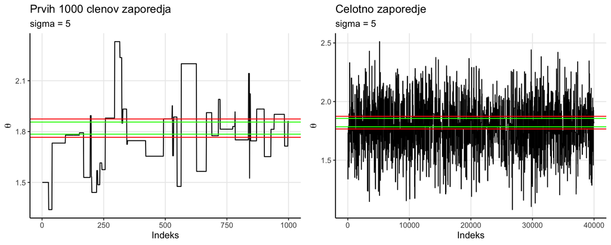

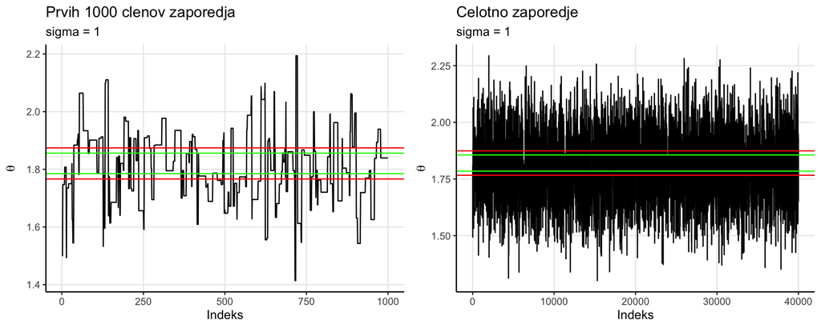

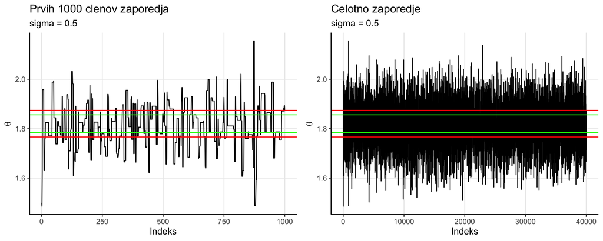

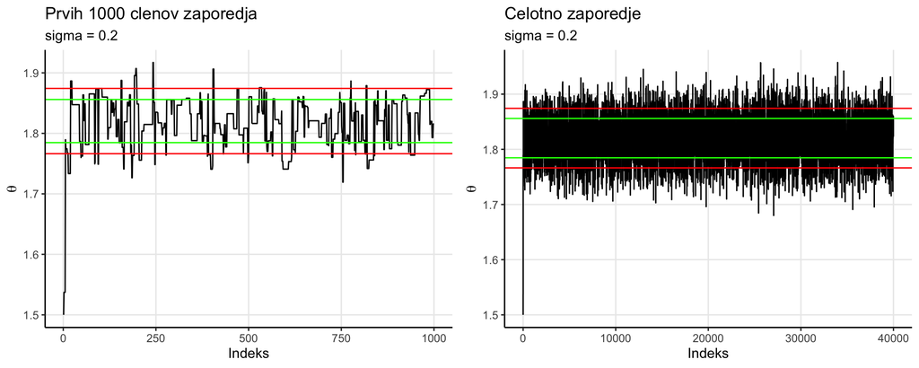

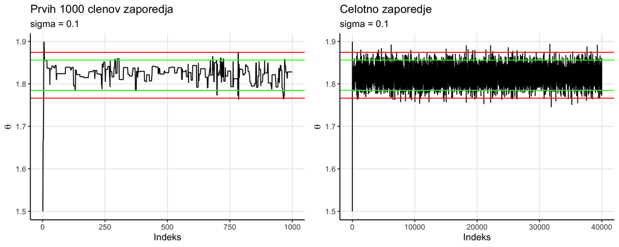

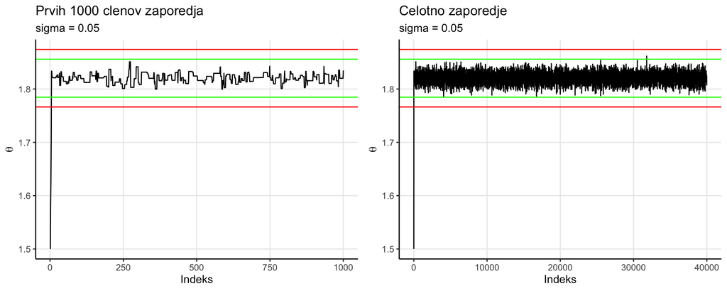

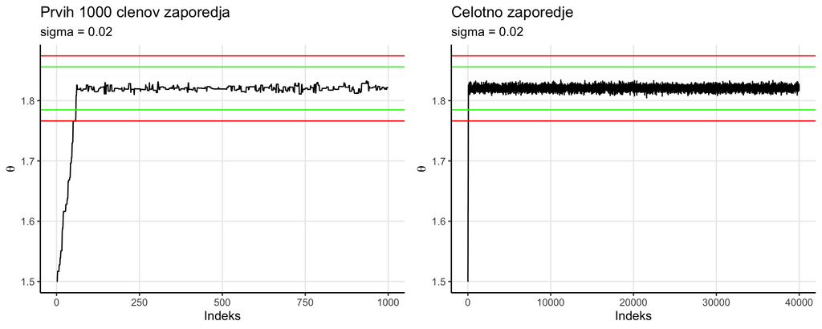

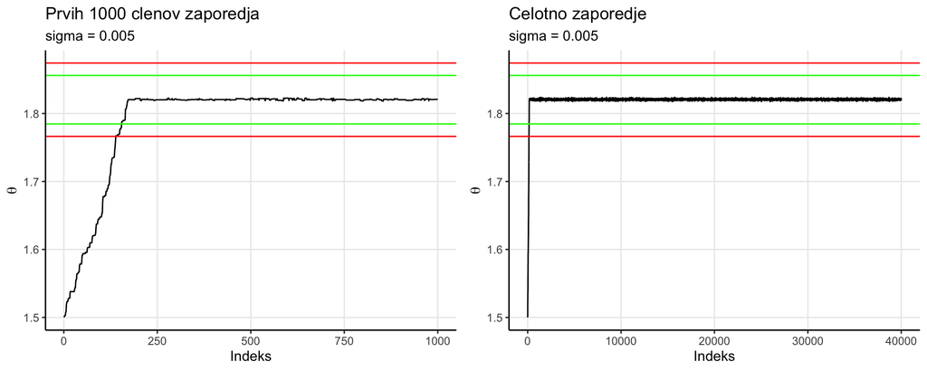

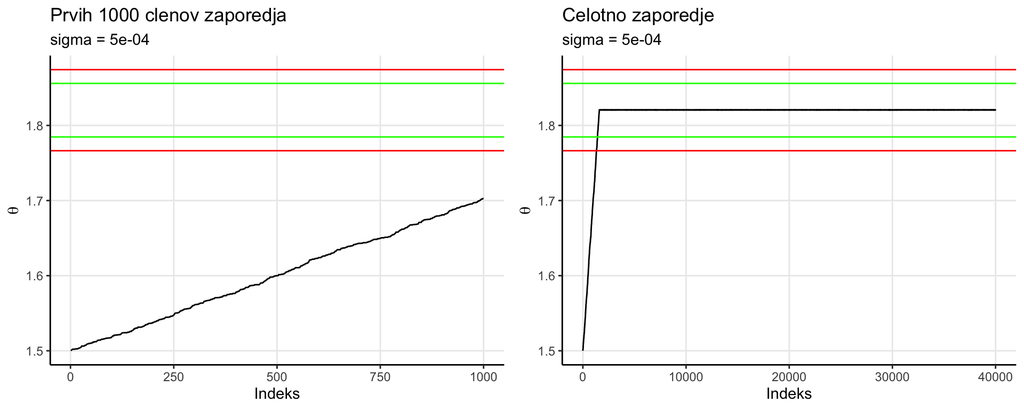

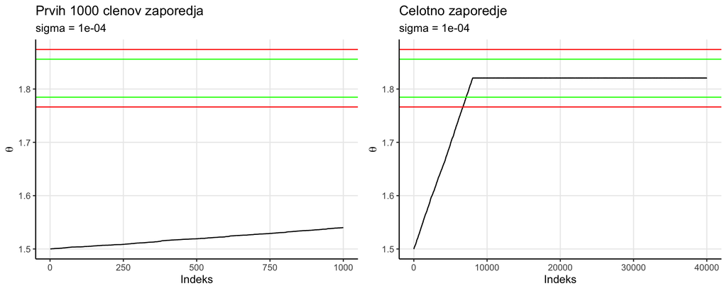

[1 more figures not shown]

## Komentar razlik

Prva razlika, ki jo najprej opazimo, je odstopanje od referncnega 95% intervala zaupanja za pravo aposteriorno porazdelitev. Pri vecji vrednosti $\sigma$ je pricakovano vec vrednosti izven intervala, pri manjsih pa za dvolj pozne clene vse lezijo znotraj intervala. Vzrok tega je simulacija kandidata $\theta^*$ iz porazdelitve $q(\cdot | \theta^{(i)})$, kjer imamo fiksno varianco ($\sigma^2$).

Ko izberemo vecjo vrednost $\sigma$ opazimo, da se vrednost $\theta$ dostikrat v iteraciji ne spremeni, torej velja $\alpha < u$. Pri majhnem $\sigma$ vidimo, da potrebujemo kar nekaj iteracij, da zaporedje zacne konvergirati proti pravi vrednosti.

Na primer v primeru, ko je $\sigma = 0.00001$ konvergence sploh ne dosezemo, pri ostalih dveh manjših variancah ($0.0005$ in $0.0001$), pa je videti pri izrisu celotnega zaporedja, da konvergira, sicer pozno, k $\theta$, ki jo iscemo. Pri vecjih $\sigma$($5, 10, 50$) pa lahko opazimo, da zaporedje nekajkrat ostane na isti $\theta$, saj imamo ob vecji varianci vecjo verjetnst za izbiro slabse $\theta$ od trenutne predlagane in zato ne sprejmemo nove. To se bolje vidi na grafih, kjer je prikazano prvih 1000 clenov zaporedja.

Zgornje lahko opisemo tudi z delezem sprejema (acceptance rate). To pomeni, da si zabelezimo kolikokrat velja pogoj $u < \alpha$ in vrednost delimo s stevilom korakov. Pri tem velja ($\theta^{(i+1)} = \theta^*$). S tem si lahko tudi nekoliko pomagamo pri dolocitvi vrednosti $\sigma$:  
- visok delez sprejema: predlagana vrednost je zelo blizu trenutni vrednosti (premiki so zelo majhni) $\rightarrow$ potrebno je povecati varianco;  
- nizek delez sprejema: imamo veliko zavrnitev (velja $\theta^{(i+1)} = \theta^{(i)}$) $\rightarrow$ potrebno je zmanjsati varianco.

Teoreticno so pokazali, da je idealni delez sprejema za enodimenzionalno normalno porazdelitev $0.45-0.5$, ta vrednost pa se priblizuje 0.23, ko se stevilo dimenzij povecuje. Ponavadi predlagano porazdelitev nastavimo tako, da algoritem sprejme priblizno 30% predlaganih vrednosti.

```r
 vrednosti_sigma = c(10, 1, 0.5, 0.05, 0.0001)
 vrednosti_delez_sprejema = NULL
 for (i in vrednosti_sigma){
   vred = mean(replicate(10, metropolis_hastings_log(n_itr, x, theta_zacetek, i, mu_0, sigma_0, TRUE)[n_itr + 1]))
   vrednosti_delez_sprejema = c(vrednosti_delez_sprejema, vred)
 }
 df_delez = data.frame("sigma" = vrednosti_sigma,
                       "delez_sprejema" = vrednosti_delez_sprejema)

 kable(df_delez, digits=c(4,4), booktabs=T) %>%
     kable_styling(latex_options=c("striped", "hold_position"), full_width=FALSE)
```

| sigma | delez_sprejema |
| --- | --- |
| 1e+01 | 0.0256 |
| 1e+00 | 0.1672 |
| 5e-01 | 0.2045 |
| 5e-02 | 0.2234 |
| 1e-04 | 0.2778 |

Torej zelimo si cim hitrejse konvergence in, da sprejmemo cim “boljsi” $\theta$ za cim boljsi opis aposteriorne porazdelitve. Posledicno, zadeve pripravimo v odvisnosti nasega problema, ker hitrejso konvergenco pridobimo z vecjo varianco(do neke tocke - grafi pri $\sigma = \{0.1, 0.2, 0.5, 1\}$), porazdelitev pa je bolje opisana, ce je varianca manjsa(veckrat sprejmemo novo $\theta$).